# **Financial Data Project #2: Using Neural Networks and Optimized Technical Indicators for Stock Trend Prediction: A Case Study on the iShares Core S&P500 ETF (IVV)**

## Feature Selection

In the paper, the authors used the Pandas Technical Analysis `Pandas TA` package, allowing up to 216 indicators. After the optimization, in Appendix A, the authors provide the best 13 indicators that I am going to replicate in this project: **EvenBetterSineWave, BOP, StochRSI_K, CorrTrend, KDJ, WilliamsR, ZScore, DEC, INC, TTM_Trend, BBP, AOBV, PVR**.

```python
#Generate a duplicate dataframe
data = df.copy()

# Even Better SineWave
data["EvenBetterSineWave"] = np.sin(np.linspace(0, np.pi * 2 * len(data) / 200, len(data)))

# Balance of Power (BOP) ---
data["BOP"] = (data["Close"] - data["Open"]) / (data["High"] - data["Low"])

# Stochastic RSI (14-period) ---
rsi_window = 14
delta = data["Close"].diff()
gain = delta.clip(lower=0)
loss = -delta.clip(upper=0)
avg_gain = gain.rolling(rsi_window).mean()
avg_loss = loss.rolling(rsi_window).mean()
rs = avg_gain / avg_loss
rsi = 100 - (100 / (1 + rs))
data["StochRSI_K"] = (rsi - rsi.rolling(14).min()) / (rsi.rolling(14).max() - rsi.rolling(14).min())

# Correlation Trend Indicator
data["CorrTrend"] = data["Close"].rolling(30).corr(pd.Series(range(len(data))))

# KDJ (K, D, J) ---
low_n = data["Low"].rolling(14).min()
high_n = data["High"].rolling(14).max()
data["K"] = 100 * (data["Close"] - low_n) / (high_n - low_n)
data["D"] = data["K"].rolling(3).mean()
data["J"] = 3 * data["K"] - 2 * data["D"]

# Williams %R (14) ---
data["WilliamsR"] = -100 * (high_n - data["Close"]) / (high_n - low_n)

# Z-Score of Close (20) ---
rolling_mean = data["Close"].rolling(20).mean()
rolling_std = data["Close"].rolling(20).std()
data["ZScore"] = (data["Close"] - rolling_mean) / rolling_std

# Decreasing / Increasing Flags ---
data["DEC"] = np.where(data["Close"].diff() < 0, 1, 0)
data["INC"] = np.where(data["Close"].diff() > 0, 1, 0)

# TTM Trend (5) ---
data["TTM_Trend"] = np.where(data["Close"] > data["Close"].rolling(5).mean(), 1, 0)

# Bollinger Bands Percent (BBP) ---
bb_mid = data["Close"].rolling(20).mean()
bb_std = data["Close"].rolling(20).std()
bb_upper = bb_mid + 2 * bb_std
bb_lower = bb_mid - 2 * bb_std
data["BBP"] = (data["Close"] - bb_lower) / (bb_upper - bb_lower)

# Average On-Balance Volume (AOBV) ---
obv = [0]
for i in range(1, len(data)):
    if data["Close"].iloc[i] > data["Close"].iloc[i-1]:
        obv.append(obv[-1] + data["Volume"].iloc[i])
    elif data["Close"].iloc[i] < data["Close"].iloc[i-1]:
        obv.append(obv[-1] - data["Volume"].iloc[i])
    else:
        obv.append(obv[-1])
data["AOBV"] = pd.Series(obv).rolling(10).mean()

# Price-Volume Rank (PVR) ---
p_change = data["Close"].pct_change()
v_change = data["Volume"].pct_change()
conditions = [
    (p_change > 0) & (v_change > 0),
    (p_change > 0) & (v_change < 0),
    (p_change < 0) & (v_change > 0),
    (p_change < 0) & (v_change < 0)
]
choices = [1, 2, 3, 4]
data["PVR"] = np.select(conditions, choices, default=np.nan)

features = [
    "EvenBetterSineWave", "BOP", "StochRSI_K", "CorrTrend", "K", "D", "J",
    "WilliamsR", "ZScore", "DEC", "INC", "TTM_Trend", "BBP", "AOBV", "PVR"
]

#Preview the data with close price
data[features + ["Close"]].head(50)
```

|  | EvenBetterSineWave | BOP | StochRSI_K | CorrTrend | K | D | J | WilliamsR | ZScore | DEC | INC | TTM_Trend | BBP | AOBV | PVR | Close |
| --- | --- | --- | --- | --- | --- | --- | --- | --- | --- | --- | --- | --- | --- | --- | --- | --- |
| 0 | 0.000000 | -0.697674 | NaN | NaN | NaN | NaN | NaN | NaN | NaN | 0 | 0 | 0 | NaN | NaN | NaN | 82.002693 |
| 1 | 0.031416 | 0.962719 | NaN | NaN | NaN | NaN | NaN | NaN | NaN | 0 | 1 | 0 | NaN | NaN | 1.0 | 86.084885 |
| 2 | 0.062801 | -0.537313 | NaN | NaN | NaN | NaN | NaN | NaN | NaN | 1 | 0 | 0 | NaN | NaN | 4.0 | 85.109085 |
| 3 | 0.094124 | -0.958801 | NaN | NaN | NaN | NaN | NaN | NaN | NaN | 1 | 0 | 0 | NaN | NaN | 4.0 | 82.649834 |
| 4 | 0.125354 | 0.259542 | NaN | NaN | NaN | NaN | NaN | NaN | NaN | 0 | 1 | 0 | NaN | NaN | 1.0 | 82.779297 |
| 5 | 0.156460 | -0.433333 | NaN | NaN | NaN | NaN | NaN | NaN | NaN | 0 | 1 | 0 | NaN | NaN | 2.0 | 82.799156 |
| 6 | 0.187412 | 0.954023 | NaN | NaN | NaN | NaN | NaN | NaN | NaN | 0 | 1 | 1 | NaN | NaN | 2.0 | 83.964111 |
| 7 | 0.218179 | 0.475177 | NaN | NaN | NaN | NaN | NaN | NaN | NaN | 0 | 1 | 1 | NaN | NaN | 1.0 | 84.412155 |
| 8 | 0.248730 | -0.366197 | NaN | NaN | NaN | NaN | NaN | NaN | NaN | 1 | 0 | 1 | NaN | NaN | 4.0 | 84.193130 |
| 9 | 0.279036 | 0.365591 | NaN | NaN | NaN | NaN | NaN | NaN | NaN | 0 | 1 | 1 | NaN | 268780.0 | 2.0 | 84.541618 |
| 10 | 0.309067 | -0.588652 | NaN | NaN | NaN | NaN | NaN | NaN | NaN | 0 | 1 | 1 | NaN | 340370.0 | 1.0 | 84.959816 |
| 11 | 0.338792 | 0.496933 | NaN | NaN | NaN | NaN | NaN | NaN | NaN | 0 | 1 | 1 | NaN | 399450.0 | 2.0 | 85.925560 |
| 12 | 0.368183 | -0.761194 | NaN | NaN | NaN | NaN | NaN | NaN | NaN | 1 | 0 | 1 | NaN | 469900.0 | 4.0 | 85.626877 |
| 13 | 0.397210 | 0.247788 | NaN | NaN | 82.319997 | NaN | NaN | -17.680003 | NaN | 0 | 1 | 1 | NaN | 551140.0 | 2.0 | 85.716522 |
| 14 | 0.425845 | 0.604167 | NaN | NaN | 93.309250 | NaN | NaN | -6.690750 | NaN | 0 | 1 | 1 | NaN | 619120.0 | 2.0 | 86.612617 |
| 15 | 0.454060 | 0.513158 | NaN | NaN | 93.760493 | 89.796580 | 101.688319 | -6.239507 | NaN | 0 | 1 | 1 | NaN | 694720.0 | 1.0 | 87.010811 |
| 16 | 0.481827 | -0.355263 | NaN | NaN | 85.835089 | 90.968277 | 75.568714 | -14.164911 | NaN | 1 | 0 | 1 | NaN | 751170.0 | 4.0 | 86.542877 |
| 17 | 0.509118 | 0.337079 | NaN | NaN | 85.329196 | 88.308259 | 79.371069 | -14.670804 | NaN | 1 | 0 | 1 | NaN | 764910.0 | 4.0 | 86.513008 |
| 18 | 0.535906 | 0.820893 | NaN | NaN | 92.263630 | 87.809305 | 101.172279 | -7.736370 | NaN | 0 | 1 | 1 | NaN | 799470.0 | 2.0 | 86.980972 |
| 19 | 0.562165 | 0.602156 | NaN | NaN | 99.885557 | 92.492794 | 114.671083 | -0.114443 | 1.615133 | 0 | 1 | 1 | 0.903783 | 830150.0 | 2.0 | 87.790283 |
| 20 | 0.587869 | -0.468217 | NaN | NaN | 78.856939 | 90.335375 | 55.900067 | -21.143061 | 1.200464 | 1 | 0 | 1 | 0.800116 | 820000.0 | 3.0 | 87.235847 |
| 21 | 0.612993 | 0.616884 | NaN | NaN | 90.740361 | 89.827619 | 92.565845 | -9.259639 | 1.427373 | 0 | 1 | 1 | 0.856843 | 809410.0 | 2.0 | 87.796623 |
| 22 | 0.637512 | -0.913330 | NaN | NaN | 50.288001 | 73.295100 | 4.273802 | -49.711999 | 0.314028 | 1 | 0 | 0 | 0.578507 | 797950.0 | 4.0 | 86.018761 |
| 23 | 0.661402 | 0.619042 | NaN | NaN | 46.893704 | 62.640689 | 15.399735 | -53.106296 | 0.399716 | 0 | 1 | 0 | 0.599929 | 785490.0 | 2.0 | 86.286385 |
| 24 | 0.684638 | -0.314518 | NaN | NaN | 44.852891 | 47.344865 | 39.868943 | -55.147109 | 0.330454 | 0 | 1 | 0 | 0.582613 | 771360.0 | 2.0 | 86.305504 |
| 25 | 0.707199 | -0.447756 | NaN | NaN | 15.495255 | 35.747284 | -25.008801 | -84.504745 | -0.269909 | 1 | 0 | 0 | 0.432523 | 731530.0 | 3.0 | 85.700142 |
| 26 | 0.729061 | -0.875622 | NaN | NaN | 0.000000 | 20.116049 | -40.232098 | -100.000000 | -1.075621 | 1 | 0 | 0 | 0.231095 | 692550.0 | 3.0 | 84.909958 |
| 27 | 0.750204 | -0.715792 | 0.000000 | NaN | 7.627003 | 7.707419 | 7.466169 | -92.372997 | -1.812764 | 1 | 0 | 0 | 0.046809 | 660610.0 | 4.0 | 84.049721 |
| 28 | 0.770606 | 0.895109 | 0.000000 | NaN | 25.848049 | 11.158351 | 55.227447 | -74.151951 | -1.146534 | 0 | 1 | 0 | 0.213366 | 620180.0 | 2.0 | 84.871773 |
| 29 | 0.790248 | -0.511238 | 0.000000 | 0.472638 | 15.395992 | 16.290348 | 13.607281 | -84.604008 | -1.574033 | 1 | 0 | 0 | 0.106492 | 570230.0 | 3.0 | 84.400223 |
| 30 | 0.809109 | -0.329334 | 0.008487 | 0.316349 | 14.583408 | 18.609150 | 6.531924 | -85.416592 | -1.759883 | 1 | 0 | 0 | 0.060029 | 548150.0 | 4.0 | 84.036980 |
| 31 | 0.827171 | 0.425284 | 0.110988 | 0.320467 | 29.166875 | 19.715425 | 48.069776 | -70.833125 | -1.040667 | 0 | 1 | 1 | 0.239833 | 525040.0 | 1.0 | 84.750679 |
| 32 | 0.844417 | -0.065691 | 0.000000 | 0.212955 | 8.160865 | 17.303716 | -10.124838 | -91.839135 | -2.048956 | 1 | 0 | 0 | -0.012239 | 483640.0 | 3.0 | 83.125786 |
| 33 | 0.860829 | -0.847582 | 0.000000 | -0.028010 | 3.076984 | 13.468241 | -17.705530 | -96.923016 | -2.400381 | 1 | 0 | 0 | -0.100095 | 434950.0 | 4.0 | 81.793953 |
| 34 | 0.876392 | -0.656564 | 0.000000 | -0.277537 | 1.135437 | 4.124429 | -4.842545 | -98.864563 | -2.597350 | 1 | 0 | 0 | -0.149338 | 377540.0 | 3.0 | 80.111702 |
| 35 | 0.891089 | -0.123077 | 0.000000 | -0.475079 | 14.068941 | 6.093788 | 30.019248 | -85.931059 | -2.191603 | 1 | 0 | 0 | -0.047901 | 295920.0 | 3.0 | 79.939659 |
| 36 | 0.904907 | 0.115607 | 0.046052 | -0.597497 | 19.024725 | 11.409701 | 34.254773 | -80.975275 | -1.997126 | 1 | 0 | 0 | 0.000718 | 202500.0 | 4.0 | 79.493591 |
| 37 | 0.917831 | 0.551280 | 0.239755 | -0.679062 | 34.134333 | 22.409333 | 57.584333 | -65.865667 | -1.295961 | 0 | 1 | 1 | 0.176010 | 121100.0 | 2.0 | 80.895454 |
| 38 | 0.929849 | -0.257732 | 0.293092 | -0.758132 | 34.111575 | 29.090211 | 44.154302 | -65.888425 | -1.259661 | 1 | 0 | 1 | 0.185085 | -6060.0 | 3.0 | 80.615105 |
| 39 | 0.940950 | -0.779944 | 0.258383 | -0.822670 | 15.738268 | 27.994725 | -8.774645 | -84.261732 | -1.637792 | 1 | 0 | 0 | 0.090552 | -139330.0 | 4.0 | 79.060303 |
| 40 | 0.951121 | 0.196850 | 0.452931 | -0.870157 | 21.512596 | 23.787480 | 16.962829 | -78.487404 | -1.380344 | 0 | 1 | 0 | 0.154914 | -263340.0 | 2.0 | 79.359779 |
| 41 | 0.960353 | 0.298611 | 0.479212 | -0.896994 | 13.865566 | 17.038810 | 7.519078 | -86.134434 | -1.457898 | 1 | 0 | 0 | 0.135526 | -396640.0 | 4.0 | 78.779907 |
| 42 | 0.968638 | 0.530309 | 0.418527 | -0.922636 | 21.597110 | 18.991757 | 26.807816 | -78.402890 | -1.125549 | 0 | 1 | 0 | 0.218613 | -460580.0 | 1.0 | 79.366188 |
| 43 | 0.975966 | -0.091503 | 0.698471 | -0.937852 | 35.371690 | 23.611456 | 58.892160 | -64.628310 | -0.696391 | 0 | 1 | 1 | 0.325902 | -380350.0 | 1.0 | 80.309273 |
| 44 | 0.982330 | -0.172039 | 0.815474 | -0.937186 | 39.913129 | 32.293977 | 55.151434 | -60.086871 | -0.491771 | 0 | 1 | 1 | 0.377057 | -191960.0 | 2.0 | 80.640625 |
| 45 | 0.987725 | 0.261905 | 0.865821 | -0.927525 | 54.107222 | 43.130681 | 76.060306 | -45.892778 | -0.314730 | 0 | 1 | 1 | 0.421317 | 36570.0 | 2.0 | 80.876373 |
| 46 | 0.992145 | -0.771186 | 0.786751 | -0.933840 | 17.028772 | 37.016374 | -22.946433 | -82.971228 | -1.203039 | 1 | 0 | 0 | 0.199240 | 77600.0 | 3.0 | 78.677956 |
| 47 | 0.995585 | -0.970853 | 0.547592 | -0.936772 | 1.220969 | 24.118988 | -44.575068 | -98.779031 | -2.309102 | 1 | 0 | 0 | -0.077275 | -88740.0 | 4.0 | 75.200119 |
| 48 | 0.998042 | 0.334645 | 1.000000 | -0.940590 | 23.579264 | 13.943002 | 42.851789 | -76.420736 | -1.632565 | 0 | 1 | 0 | 0.091859 | -199150.0 | 2.0 | 76.438820 |
| 49 | 0.999515 | -0.048110 | 0.789781 | -0.939410 | 8.768278 | 11.189504 | 3.925827 | -91.231722 | -2.070699 | 1 | 0 | 0 | -0.017675 | -314960.0 | 3.0 | 74.612755 |

## Feature Correlation with Next-Day Market Direction

Now, to identify which technical indicators have the strongest linear relationship with next-day market movements. To achieve this, I define a binary **target variable** ($\Gamma$) representing whether the ETF's next-day opening price is higher than today's open with the following logic:

$$\Gamma_t = \begin{cases} 1, & \text{if } \text{Open}_{t+1} > \text{Open}_t \\ 0, & \text{otherwise} \end{cases}$$

I then construct our feature matrix (`X`) using the engineered indicators developed earlier, such as momentum, volatility, and volume-based metrics. And standardize them (z-score normalization) to ensure fair comparison across scales.

After cleaning missing data, I calculate the Pearson correlation coefficient between each standardized feature and the binary target to have an interpretable, first-pass measure of each feature's directional influence on price movements:

- A positive correlation means the feature tends to increase when the next day opens higher
- A negative correlation means the feature tends to rise when the next day opens lower

```python
# Define binary target Γ_t = 1 if next day open > today open
data["Target"] = np.where(data["Open"].shift(-1) > data["Open"], 1, 0)
data = data.dropna(subset=["Target"]).reset_index(drop=True)

# Feature matrix and target
X = data[features]
y = data["Target"].astype(int).values

# Standardize features (z-score)
X = (X - X.mean()) / X.std()

# Compute Pearson correlations between each feature and the target
corrs = []
for col in X.columns:
    valid_idx = X[col].notna()
    if valid_idx.sum() > 2:
        corr = np.corrcoef(X.loc[valid_idx, col], y[valid_idx])[0, 1]
    else:
        corr = np.nan
    corrs.append({"Feature": col, "Correlation_with_Target": round(corr, 4) if pd.notna(corr) else np.nan})

corr_df = pd.DataFrame(corrs).sort_values(by="Correlation_with_Target", ascending=False)
print("\n=== Correlation of Each Feature with Target ===")
print(corr_df)
```

```
=== Correlation of Each Feature with Target ===
               Feature  Correlation_with_Target
1                  BOP                   0.6708
10                 INC                   0.4584
6                    J                   0.4353
11           TTM_Trend                   0.3338
4                    K                   0.2776
7            WilliamsR                   0.2776
8               ZScore                   0.2465
12                 BBP                   0.2465
2           StochRSI_K                   0.1827
5                    D                   0.0901
13                AOBV                   0.0293
3            CorrTrend                   0.0209
0   EvenBetterSineWave                  -0.0141
14                 PVR                  -0.3958
9                  DEC                  -0.4567
```

After identifying the most relevant features, I evaluate their predictive strength using a Logistic Regression classifier combined with 10-fold cross-validation.

Before training, missing values are imputed using the mean strategy, maintaining data consistency without biasing the sample distribution. The dataset is then divided into 10 folds; in each iteration, 9 folds are used for training while 1 is reserved for testing, and this process repeats across all folds.

```python
# K-Fold Cross-Validation (10 folds)
from sklearn.impute import SimpleImputer
from sklearn.linear_model import LogisticRegression
from sklearn.model_selection import KFold

# --- Xử lý missing values ---
imputer = SimpleImputer(strategy="mean")
X = pd.DataFrame(imputer.fit_transform(X), columns=X.columns)

# --- K-Fold ---
kf = KFold(n_splits=10, shuffle=True, random_state=42)
accuracies = []

for train_idx, test_idx in kf.split(X):
    X_train, X_test = X.iloc[train_idx], X.iloc[test_idx]
    y_train, y_test = y[train_idx], y[test_idx]

    model = LogisticRegression(max_iter=500)
    model.fit(X_train, y_train)

    preds = np.where(model.predict_proba(X_test)[:, 1] > 0.5, 1, 0)
    acc = (preds == y_test).mean()
    accuracies.append(acc)

print(f"\nMean CV Accuracy: {np.mean(accuracies)*100:.2f}% (± {np.std(accuracies)*100:.2f}%)")
```

```
Mean CV Accuracy: 80.70% (± 2.00%)
```

From the Cross-validation result, for each fold, the logistic regression model predicts the probability of an upward movement (next-day open higher than today). Predictions above 0.5 are classified as bullish signals (`1`), and below 0.5 as bearish (`0`). The model achieves an average cross-validated accuracy of ~80.7% (±2.0%), indicating that the selected feature set carries significant predictive information about next-day market direction.

This result confirms that even a simple linear classifier, when applied to well-engineered technical indicators, can capture short-term dependencies in ETF price behavior — providing a solid baseline before moving on to more complex machine learning architectures.

## Result Summary

```
=== Cross-Validation Summary ===
              Metric  Value
0  Mean Accuracy (%)   80.7
1   Std Accuracy (%)    2.0
```

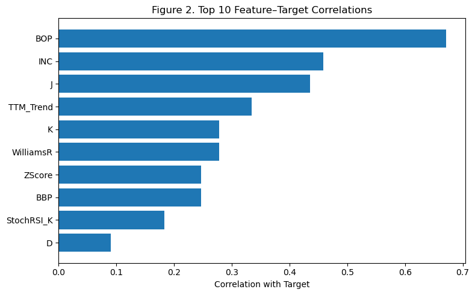

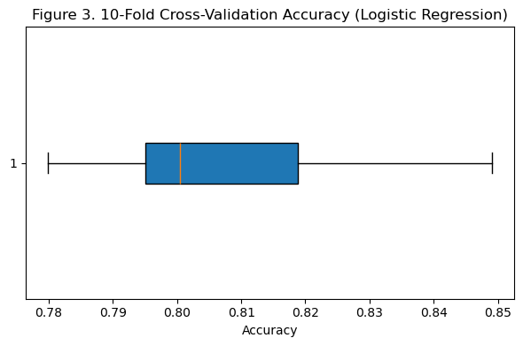

```python
# Cross-validation summary
cv_summary = pd.DataFrame({
    "Metric": ["Mean Accuracy (%)", "Std Accuracy (%)"],
    "Value": [np.mean(accuracies)*100, np.std(accuracies)*100]
}).round(2)
print("\n=== Cross-Validation Summary ===")
print(cv_summary)

# Plot correlation of top 10 features
plt.figure(figsize=(8, 5))
plt.barh(corr_df["Feature"].head(10), corr_df["Correlation_with_Target"].head(10))
plt.title("Figure 2. Top 10 Feature–Target Correlations")
plt.xlabel("Correlation with Target")
plt.gca().invert_yaxis()
plt.tight_layout()
plt.show()

# Plot cross-validation accuracy distribution
plt.figure(figsize=(6, 4))
plt.boxplot(accuracies, vert=False, patch_artist=True)
plt.title("Figure 3. 10-Fold Cross-Validation Accuracy (Logistic Regression)")
plt.xlabel("Accuracy")
plt.tight_layout()
plt.show()
```

Based on the training result, Figure 2 gives us the top 10 features that have highest target correlation, and our model achieves an accuracy above 80%.

## Conclusion

This project successfully replicated and extended the methodology of Sagaceta-Mejía et al. (2024) using the iShares Core S&P 500 ETF (IVV) to explore how optimized technical indicators improve the prediction of next-day market direction. By constructing fifteen key features across momentum, trend, volume, volatility, and statistical categories, and evaluating their correlation with subsequent price movements, we identified Balance of Power (BOP), Increment Flag (INC), and KDJ oscillators as the most informative indicators for the U.S. market.

From a practical standpoint, this work demonstrates how intelligent feature optimization enhances model interpretability and computational efficiency while preserving predictive value. It provides a scalable framework for applying machine learning to financial forecasting, emphasizing that effective feature selection is the cornerstone of reliable and economically meaningful market prediction.